```python
#Importing required libraries
import tensorflow as tf
import numpy as np
import os
from matplotlib import pyplot as plt
import random
random.seed(0)
import warnings
warnings.filterwarnings("ignore")
import pandas as pd
import matplotlib.patches as patches
import cv2
from tensorflow.keras.applications.mobilenet import preprocess_input
from PIL import Image
import csv
from tensorflow.keras.applications.mobilenet import MobileNet
from tensorflow.keras.models import Model
from tensorflow.keras.layers import Conv2D, Reshape
from google.colab import drive
drive.mount("/content/drive")
```

# Part-A

• **DOMAIN**: Entertainment

• **DATA DESCRIPTION**: The dataset comprises of images and its mask for corresponding human face.

• **PROJECT OBJECTIVE**: To build a face detection system.

# Steps and tasks: [ Total Score: 20 Marks]

# 1. Import and Understand the data [7 Marks]

# A. Import and read ‘images.npy’. [1 Marks]

```python
#Loading the file
img_data = np.load('/content/drive/My Drive/CV-2 Dataset/images (3).npy', allow_pickle=True)
```

# B. Split the data into Features(X) & labels(Y). Unify shape of all the images. [3 Marks]

Imp Note: Replace all the pixels within masked area with 1.

Hint: X will comprise of array of image whereas Y will comprise of coordinates of the mask(human face). Observe: data[0], data[0][0], data[0][1]

```python
img_data[0]
```

```
array([array([[[42, 37, 34],
               [56, 51, 48],
               [71, 66, 63],
               ...,
               [23, 33, 34],
               [26, 36, 37],
               [28, 38, 39]],

              [[40, 35, 32],
               [51, 46, 43],
               [64, 59, 56],
               ...,
               [27, 36, 35],
               [24, 33, 32],
               [26, 35, 34]],

              [[43, 38, 35],
               [51, 46, 43],
               [61, 56, 53],
               ...,
               [28, 30, 27],
               [33, 35, 32],
               [35, 37, 34]],

              ...,

              [[56, 47, 40],
               [57, 48, 41],
               [61, 52, 45],
               ...,
               [67, 48, 42],
               [55, 35, 28],
               [60, 40, 33]],

              [[53, 44, 37],
               [54, 45, 38],
               [57, 48, 41],
               ...,
               [59, 40, 34],
               [60, 40, 33],
               [54, 34, 27]],

              [[53, 44, 37],
               [54, 45, 38],
               [57, 48, 41],
               ...,
               [59, 40, 34],
               [70, 50, 43],
               [64, 44, 37]]], dtype=uint8),
       list([{'label': ['Face'], 'notes': '', 'points': [{'x': 0.08615384615384615, 'y': 0.3063063063063063}, {'x': 0.1723076923076923, 'y': 0.45345345345345345}], 'imageWidth': 650, 'imageHeight': 333}, {'label': ['Face'], 'notes': '', 'points': [{'x': 0.583076923076923, 'y': 0.2912912912912913}, {…
      dtype=object)
```

```python
img_data[0][0]
```

```
array([[[42, 37, 34],
        [56, 51, 48],
        [71, 66, 63],
        ...,
        [23, 33, 34],
        [26, 36, 37],
        [28, 38, 39]],

       [[40, 35, 32],
        [51, 46, 43],
        [64, 59, 56],
        ...,
        [27, 36, 35],
        [24, 33, 32],
        [26, 35, 34]],

       [[43, 38, 35],
        [51, 46, 43],
        [61, 56, 53],
        ...,
        [28, 30, 27],
        [33, 35, 32],
        [35, 37, 34]],

       ...,

       [[56, 47, 40],
        [57, 48, 41],
        [61, 52, 45],
        ...,
        [67, 48, 42],
        [55, 35, 28],
        [60, 40, 33]],

       [[53, 44, 37],
        [54, 45, 38],
        [57, 48, 41],
        ...,
        [59, 40, 34],
        [60, 40, 33],
        [54, 34, 27]],

       [[53, 44, 37],
        [54, 45, 38],
        [57, 48, 41],
        ...,
        [59, 40, 34],
        [70, 50, 43],
        [64, 44, 37]]], dtype=uint8)
```

```python
img_data[0][1]
```

```
[{'label': ['Face'],
  'notes': '',
  'points': [{'x': 0.08615384615384615, 'y': 0.3063063063063063},
   {'x': 0.1723076923076923, 'y': 0.45345345345345345}],
  'imageWidth': 650,
  'imageHeight': 333},
 {'label': ['Face'],
  'notes': '',
  'points': [{'x': 0.583076923076923, 'y': 0.2912912912912913},
   {'x': 0.6584615384615384, 'y': 0.46846846846846846}],
  'imageWidth': 650,
  'imageHeight': 333}]
```

[figure not shown]

```python
fig = plt.figure(figsize = (15, 7.2))
ax = fig.add_subplot(1, 1, 1)
plt.axis('off')
plt.imshow(img_data[10][0])
plt.show()
```

```python
from tensorflow.keras.applications.mobilenet import preprocess_input

img_height = 224
img_width = 224

y = np.zeros((int(img_data.shape[0]), img_height, img_width))
X = np.zeros((int(img_data.shape[0]),img_height, img_width,3))


for index in range(img_data.shape[0]):
  img = img_data[index][0]
  img = cv2.resize(img, dsize=(img_height, img_width), interpolation=cv2.INTER_CUBIC)

  try:
    img = img[:,:,:3]
  except:
    continue

  X[index] = preprocess_input(np.array(img, dtype=np.float32))

  for i in img_data[index][1]:
    x1 = int(i["points"][0]['x'] * img_width)
    x2 = int(i["points"][1]['x'] * img_width)
    y1 = int(i["points"][0]['y'] * img_height)
    y2 = int(i["points"][1]['y'] * img_height)

    y[index][y1:y2, x1:x2] = 1

print(X.shape, y.shape)
```

```
(409, 224, 224, 3) (409, 224, 224)
```

# C. Split the data into train and test[400:9]. [1 Marks]

```python
from sklearn.model_selection import train_test_split
X_train,X_test, y_train,y_test = train_test_split(X,y, test_size = 0.02)

print(X_train.shape, X_test.shape)
```

```
(400, 224, 224, 3) (9, 224, 224, 3)
```

# D. Select random image from the train data and display original image and masked image. [2 Marks]

```
WARNING:matplotlib.image:Clipping input data to the valid range for imshow with RGB data ([0..1] for floats or [0..255] for integers).
```

[figure not shown]

```python
import random

n = 3
fig = plt.figure(figsize=(10, 10))
a = fig.add_subplot(1, 2, 1)
plt.imshow(X_train[n])
a = fig.add_subplot(1, 2, 2)
plt.imshow(y_train[n])
```

# 2. Model building [11 Marks]

# A. Design a face mask detection model. [4 Marks]

Hint: 1. Use MobileNet architecture for initial pre-trained non-trainable layers.

Hint: 2. Add appropriate Upsampling layers to imitate U-net architecture.

```python
from keras.applications.mobilenet import MobileNet
from keras.layers import Concatenate, Conv2D, Reshape, UpSampling2D
from keras.models import Model

img_height = 224
img_width = 224
ALPHA = 1

def create_model(trainable=False):
    model = MobileNet(input_shape=(img_height, img_width, 3), include_top=False, alpha=ALPHA, weights="imagenet")

    for layer in model.layers:
      layer.trainable = trainable

    block0 = model.layers[0].input
    block1 = model.get_layer("conv_pw_1_relu").output
    block2 = model.get_layer("conv_pw_2_relu").output
    block3 = model.get_layer("conv_pw_3_relu").output
    block5 = model.get_layer("conv_pw_5_relu").output
    block11 = model.get_layer("conv_pw_11_relu").output
    block13 = model.get_layer("conv_pw_13_relu").output

    x = Concatenate()([UpSampling2D()(block13), block11])
    x = Concatenate()([UpSampling2D()(x), block5])
    x = Concatenate()([UpSampling2D()(x), block3])
    x = Concatenate()([UpSampling2D()(x), block1])
    x = Concatenate()([UpSampling2D()(x), block0])

    x = Conv2D(1, kernel_size=1, activation="sigmoid")(x)
    x = Reshape((img_height, img_width))(x)

    return Model(inputs=model.input, outputs=x)
```

```python
model = create_model()

# Print summary
model.summary()
```

```
Model: "model"
__________________________________________________________________________________________________
 Layer (type)                   Output Shape         Param #     Connected to
==================================================================================================
 input_1 (InputLayer)           [(None, 224, 224, 3  0           []
                                )]

 conv1 (Conv2D)                 (None, 112, 112, 32  864         ['input_1[0][0]']
                                )

 conv1_bn (BatchNormalization)  (None, 112, 112, 32  128         ['conv1[0][0]']
                                )

 conv1_relu (ReLU)              (None, 112, 112, 32  0           ['conv1_bn[0][0]']
                                )

 conv_dw_1 (DepthwiseConv2D)    (None, 112, 112, 32  288         ['conv1_relu[0][0]']
                                )

 conv_dw_1_bn (BatchNormalizati  (None, 112, 112, 32  128        ['conv_dw_1[0][0]']
 on)                            )

 conv_dw_1_relu (ReLU)          (None, 112, 112, 32  0           ['conv_dw_1_bn[0][0]']
                                )

 conv_pw_1 (Conv2D)             (None, 112, 112, 64  2048        ['conv_dw_1_relu[0][0]']
                                )

 conv_pw_1_bn (BatchNormalizati  (None, 112, 112, 64  256        ['conv_pw_1[0][0]']
 on)                            )

 conv_pw_1_relu (ReLU)          (None, 112, 112, 64  0           ['conv_pw_1_bn[0][0]']
                                )

 conv_pad_2 (ZeroPadding2D)     (None, 113, 113, 64  0           ['conv_pw_1_relu[0][0]']
                                )

 conv_dw_2 (DepthwiseConv2D)    (None, 56, 56, 64)   576         ['conv_pad_2[0][0]']

 conv_dw_2_bn (BatchNormalizati  (None, 56, 56, 64)  256         ['conv_dw_2[0][0]']
```

[output cut: 195 more lines]

```
 up_sampling2d_4 (UpSampling2D)  (None, 224, 224, 19  0          ['concatenate_3[0][0]']
                                84)

 concatenate_4 (Concatenate)    (None, 224, 224, 19  0           ['up_sampling2d_4[0][0]',
                                87)                               'input_1[0][0]']

 conv2d (Conv2D)                (None, 224, 224, 1)  1988        ['concatenate_4[0][0]']

 reshape (Reshape)              (None, 224, 224)     0           ['conv2d[0][0]']

==================================================================================================
Total params: 3,230,852
Trainable params: 1,988
Non-trainable params: 3,228,864
__________________________________________________________________________________________________
```

# B. Design your own Dice Coefficient and Loss function. [2 Marks]

```python
#Designing Dice Coefficient

from keras.backend import epsilon

def dice_coefficient(y_true, y_pred):
    numerator = 2 * tf.reduce_sum(y_true * y_pred)
    denominator = tf.reduce_sum(y_true + y_pred)

    return numerator / (denominator + tf.keras.backend.epsilon())
```

```python
#Designing Loss Function

from keras.losses import binary_crossentropy
from keras.backend import log

def loss(y_true, y_pred):
    return binary_crossentropy(y_true, y_pred) - log(dice_coefficient(y_true, y_pred) + epsilon())
```

# C. Train and tune the model as required. [3 Marks]

```python
optimizer = tf.keras.optimizers.Adam(lr=1e-3)
model.compile(loss=loss, optimizer = optimizer, metrics=[dice_coefficient])
```

```
WARNING:absl:`lr` is deprecated, please use `learning_rate` instead, or use the legacy optimizer, e.g.,tf.keras.optimizers.legacy.Adam.
```

```python
from keras.callbacks import ModelCheckpoint, EarlyStopping, ReduceLROnPlateau
callbacks = [
    ReduceLROnPlateau(monitor='val_loss', factor=0.1, patience=4),
    EarlyStopping(monitor='val_loss', patience=10, restore_best_weights=False)
]
```

```python
model.fit(X_train, y_train, validation_data=(X_test, y_test),epochs = 10,verbose=1,
          batch_size=3,callbacks=callbacks)
```

```
<keras.callbacks.History at 0x7f3d080ba4c0>
```

# D. Evaluate and share insights on performance of the model. [2 Marks]

```python
model.evaluate(X_test, y_test)
```

```
[0.6452799439430237, 0.6680377721786499]
```

# 3. Test the model predictions on the test image: ‘image with index 3 in the test data’ and visualise the predicted masks on the faces in the image. [2 Marks]

```python
test_image = X_test[3]
resized_image = cv2.resize(test_image, (img_height, img_width))
```

```python
prediction = model.predict(np.array([resized_image]))
prediction
```

```
array([[[2.0277358e-04, 2.1056499e-04, 1.0809263e-04, ...,
         8.7844055e-06, 1.1584937e-05, 1.1599153e-05],
        [2.0417279e-04, 2.1091742e-04, 1.0816872e-04, ...,
         8.7761237e-06, 1.1568068e-05, 1.1488712e-05],
        [2.0376767e-04, 2.0169090e-04, 2.6146689e-04, ...,
         1.4678386e-05, 7.6786764e-06, 7.6793931e-06],
        ...,
        [1.0219602e-04, 1.0210066e-04, 1.2431246e-04, ...,
         2.6043419e-06, 1.1722183e-06, 1.1815181e-06],
        [1.4398831e-04, 1.4409571e-04, 7.8628109e-05, ...,
         1.4961458e-06, 1.7381265e-06, 1.7554312e-06],
        [1.4320429e-04, 1.4331097e-04, 7.8278361e-05, ...,
         1.4949405e-06, 1.7393518e-06, 1.7348343e-06]]], dtype=float32)
```

```python
predicted_mask = cv2.resize((1.0*(prediction[0] > 0.5)), (224,224))
```

```
WARNING:matplotlib.image:Clipping input data to the valid range for imshow with RGB data ([0..1] for floats or [0..255] for integers).
```

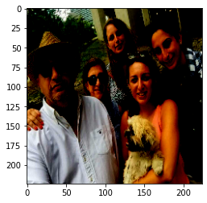

```python
plt.imshow(test_image)
```

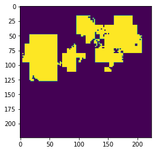

```python
plt.imshow(predicted_mask)
```

## Part B- 10 Marks

DOMAIN: Entertainment

• **DATA DESCRIPTION**: The dataset comprises of face images.

• **PROJECT OBJECTIVE**: To create an image dataset to be used by AI team build an image classifier data. Profile images of people are given.

**Steps and tasks: [ Total Score: 10 Marks]**

# 1. Read/import images from folder ‘training_images’. [2 Marks]

```python
from zipfile import ZipFile
import os
import numpy as np
import cv2
import tensorflow as tf

image_path = "/content/drive/My Drive/CV-2 Dataset/training_images-20211126T092819Z-001 (1).zip"

with ZipFile(image_path, 'r') as z:
  z.extractall()
```

```python
img_loc = z.filelist[0].filename.split("/")[0]
img_loc
```

```
'training_images'
```

```python
image_names = [os.path.join(img_loc,i) for i in os.listdir(img_loc)]

image_list = []
for imgs in image_names:
  img = cv2.imread(imgs)
  image_list.append(img)
image_list = np.array(image_list)
print(image_list.shape)
```

```
(1091, 600, 600, 3)
```

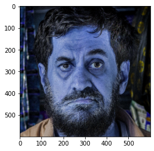

```python
import matplotlib.pyplot as plt
plt.imshow(image_list[50]) # checking random image to see if read properly
```

# 2. Write a loop which will iterate through all the images in the ‘training_images’ folder and detect the faces present on all the images. [3 Marks]

Hint: You can use ’haarcascade_frontalface_default.xml’ from internet to detect faces which is available open source.

```python
!wget https://raw.githubusercontent.com/opencv/opencv/master/data/haarcascades/haarcascade_frontalface_default.xml
```

```
--2023-03-20 05:42:52--  https://raw.githubusercontent.com/opencv/opencv/master/data/haarcascades/haarcascade_frontalface_default.xml
Resolving raw.githubusercontent.com (raw.githubusercontent.com)... 185.199.108.133, 185.199.109.133, 185.199.110.133, ...
Connecting to raw.githubusercontent.com (raw.githubusercontent.com)|185.199.108.133|:443... connected.
HTTP request sent, awaiting response... 200 OK
Length: 930127 (908K) [text/plain]
Saving to: ‘haarcascade_frontalface_default.xml’

haarcascade_frontal 100%[===================>] 908.33K  --.-KB/s    in 0.03s

2023-03-20 05:42:52 (34.8 MB/s) - ‘haarcascade_frontalface_default.xml’ saved [930127/930127]
```

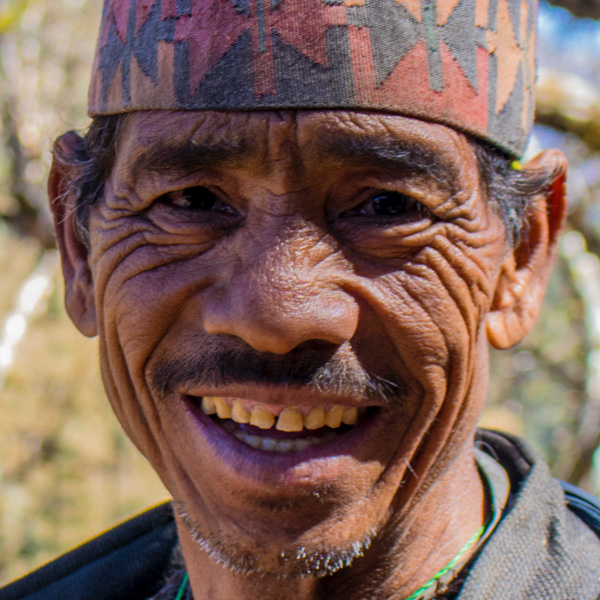

```python
from google.colab.patches import cv2_imshow

face_cascade = cv2.CascadeClassifier('haarcascade_frontalface_default.xml')

for imgs in image_list:
  gray = cv2.cvtColor(imgs,cv2.COLOR_BGR2GRAY)
  faces = face_cascade.detectMultiScale(gray,1.1,45)

  for (x, y, w, h) in faces:
    cv2.rectangle(imgs, (x, y), (x+w, y+h), (255, 0, 0), 2)
    cv2.putText(imgs, "HaarCascadeClassifier", (int((x+w)*0.75),y-3),cv2.FONT_HERSHEY_SIMPLEX,0.5,(0,0,255))

cv2_imshow(img)
```

# 3. From the same loop above, extract metadata of the faces and write into a DataFrame. [3 Marks]

```python
import pandas as pd

img_metadata = pd.DataFrame(columns=['x','y','w','h','Total_Faces','Image_Name'])

for imgs, fnames in zip(image_list,image_names):
  gray = cv2.cvtColor(imgs,cv2.COLOR_BGR2GRAY)
  faces = face_cascade.detectMultiScale(gray,1.1,4)

  for (x,y,w,h) in faces:
    temp_dict = {'x':x,
                'y':y,
                'w':w,
                'h':h,
                'Total_Faces':len(faces),
                'Image_Name':fnames}
  img_metadata = img_metadata.append(temp_dict,ignore_index=True)
```

```python
img_metadata.head()
```

|  | x | y | w | h | Total_Faces | Image_Name |
| --- | --- | --- | --- | --- | --- | --- |
| 0 | 94 | 148 | 412 | 412 | 1 | training_images/real_00754.jpg |
| 1 | 56 | 179 | 380 | 380 | 1 | training_images/real_00499.jpg |
| 2 | 84 | 128 | 73 | 73 | 2 | training_images/real_00423.jpg |
| 3 | 81 | 121 | 426 | 426 | 1 | training_images/real_00151.jpg |
| 4 | 35 | 28 | 473 | 473 | 1 | training_images/real_01032.jpg |

```python
img_metadata['Image_Name'] = img_metadata['Image_Name'].str[-14:]
```

```python
img_metadata.head()
```

|  | x | y | w | h | Total_Faces | Image_Name |
| --- | --- | --- | --- | --- | --- | --- |
| 0 | 94 | 148 | 412 | 412 | 1 | real_00754.jpg |
| 1 | 56 | 179 | 380 | 380 | 1 | real_00499.jpg |
| 2 | 84 | 128 | 73 | 73 | 2 | real_00423.jpg |
| 3 | 81 | 121 | 426 | 426 | 1 | real_00151.jpg |
| 4 | 35 | 28 | 473 | 473 | 1 | real_01032.jpg |

# 4. Save the output Dataframe in .csv format. [2 Marks]

```python
img_metadata.to_csv('image_metadata.csv')
data = pd.read_csv('image_metadata.csv')
data.head()
```

|  | Unnamed: 0 | x | y | w | h | Total_Faces | Image_Name |
| --- | --- | --- | --- | --- | --- | --- | --- |
| 0 | 0 | 94 | 148 | 412 | 412 | 1 | real_00754.jpg |
| 1 | 1 | 56 | 179 | 380 | 380 | 1 | real_00499.jpg |
| 2 | 2 | 84 | 128 | 73 | 73 | 2 | real_00423.jpg |
| 3 | 3 | 81 | 121 | 426 | 426 | 1 | real_00151.jpg |
| 4 | 4 | 35 | 28 | 473 | 473 | 1 | real_01032.jpg |

# Part C - 30 Marks

• **DOMAIN**: Face Recognition

• **CONTEXT**: Company X intends to build a face identification model to recognise human faces.

• **DATA DESCRIPTION**: The dataset comprises of images and its mask where there is a human face.

**Steps and tasks: [ Total Score: 30 Marks]**

# 1. Unzip, read and Load data(‘PINS.zip’) into session. [2 Marks]

```python
from zipfile import ZipFile
import os
import numpy as np
import cv2
import tensorflow as tf

image_path = "/content/drive/My Drive/CV-2 Dataset/PINS.zip"

with ZipFile(image_path, 'r') as z:
  z.extractall()
```

# 2. Write function to create metadata of the image. [4 Marks]

Hint: Metadata means derived information from the available data which can be useful for particular problem statement.

```python
import os

class IdentityMetadata():
    def __init__(self, base, name, file):
        # print(base, name, file)
        # dataset base directory
        self.base = base
        # identity name
        self.name = name
        # image file name
        self.file = file

    def __repr__(self):
        return self.image_path()

    def image_path(self):
        return os.path.join(self.base, self.name, self.file)
```

# 3. Write a loop to iterate through each and every image and create metadata for all the images. [4 Marks]

```python
def load_metadata(path):
    metadata = []
    for i in os.listdir(path):
        for f in os.listdir(os.path.join(path, i)):
            # Check file extension. Allow only jpg/jpeg' files.
            ext = os.path.splitext(f)[1]
            if ext == '.jpg' or ext == '.jpeg':
                metadata.append(IdentityMetadata(path, i, f))
    return np.array(metadata)
metadata = load_metadata('PINS')
```

```python
import cv2
def load_image(path):
    img = cv2.imread(path, 1)
    # OpenCV loads images with color channels
    # in BGR order. So we need to reverse them
    return img[...,::-1]
```

```python
load_image('PINS/pins_Aaron Paul/Aaron Paul101_247.jpg')
```

[output not shown]

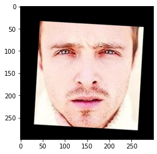

```python
import matplotlib.pyplot as plt

plt.imshow(load_image('PINS/pins_Aaron Paul/Aaron Paul101_247.jpg'))
```

# 4. Generate Embeddings vectors on the each face in the dataset. [4 Marks]

Hint: Use ‘vgg_face_weights.h5’

```python
from tensorflow.keras.models import Sequential
from tensorflow.keras.layers import ZeroPadding2D, Convolution2D, MaxPooling2D, Dropout, Flatten, Activation

def vgg_face():
    model = Sequential()
    model.add(ZeroPadding2D((1,1),input_shape=(224,224, 3)))
    model.add(Convolution2D(64, (3, 3), activation='relu'))
    model.add(ZeroPadding2D((1,1)))
    model.add(Convolution2D(64, (3, 3), activation='relu'))
    model.add(MaxPooling2D((2,2), strides=(2,2)))

    model.add(ZeroPadding2D((1,1)))
    model.add(Convolution2D(128, (3, 3), activation='relu'))
    model.add(ZeroPadding2D((1,1)))
    model.add(Convolution2D(128, (3, 3), activation='relu'))
    model.add(MaxPooling2D((2,2), strides=(2,2)))

    model.add(ZeroPadding2D((1,1)))
    model.add(Convolution2D(256, (3, 3), activation='relu'))
    model.add(ZeroPadding2D((1,1)))
    model.add(Convolution2D(256, (3, 3), activation='relu'))
    model.add(ZeroPadding2D((1,1)))
    model.add(Convolution2D(256, (3, 3), activation='relu'))
    model.add(MaxPooling2D((2,2), strides=(2,2)))

    model.add(ZeroPadding2D((1,1)))
    model.add(Convolution2D(512, (3, 3), activation='relu'))
    model.add(ZeroPadding2D((1,1)))
    model.add(Convolution2D(512, (3, 3), activation='relu'))
    model.add(ZeroPadding2D((1,1)))
    model.add(Convolution2D(512, (3, 3), activation='relu'))
    model.add(MaxPooling2D((2,2), strides=(2,2)))

    model.add(ZeroPadding2D((1,1)))
    model.add(Convolution2D(512, (3, 3), activation='relu'))
    model.add(ZeroPadding2D((1,1)))
    model.add(Convolution2D(512, (3, 3), activation='relu'))
    model.add(ZeroPadding2D((1,1)))
    model.add(Convolution2D(512, (3, 3), activation='relu'))
    model.add(MaxPooling2D((2,2), strides=(2,2)))

    model.add(Convolution2D(4096, (7, 7), activation='relu'))
    model.add(Dropout(0.5))
    model.add(Convolution2D(4096, (1, 1), activation='relu'))
    model.add(Dropout(0.5))
    model.add(Convolution2D(2622, (1, 1)))
    model.add(Flatten())
    model.add(Activation('softmax'))
    return model
```

```python
model = vgg_face()
model.load_weights('/content/drive/My Drive/CV-2 Dataset/vgg_face_weights.h5')
```

```python
model.layers[0], model.layers[-2]
```

```
(<keras.layers.reshaping.zero_padding2d.ZeroPadding2D at 0x7fea566cefa0>,
 <keras.layers.reshaping.flatten.Flatten at 0x7fea56663610>)
```

```python
from tensorflow.keras.models import Model
vgg_face_descriptor = Model(inputs=model.layers[0].input, outputs=model.layers[-2].output)
```

```python
img_path = metadata[0].image_path()
img = load_image(img_path)

img = (img / 255.).astype(np.float32)

img = cv2.resize(img, dsize = (224,224))
print(img.shape)

embedding_vector = vgg_face_descriptor.predict(np.expand_dims(img, axis=0))[0]
print(embedding_vector.shape)
```

```
(224, 224, 3)
(2622,)
```

```python
embedding_vector[0], type(embedding_vector), type(embedding_vector[0])
```

```
(0.022779085, numpy.ndarray, numpy.float32)
```

```python
from tqdm.notebook import tqdm

embeddings = []
embeddings = np.zeros((metadata.shape[0], 2622))
for i, meta in tqdm(enumerate(metadata)):
  try:
    image = load_image(str(meta))
    image = (image/255.).astype(np.float32)
    image = cv2.resize(image, (224, 224))
    embeddings[i] = vgg_face_descriptor.predict(np.expand_dims(image, axis = 0))[0]
  except:
    embeddings[i] = np.zeros(2622)
```

```
Streaming output truncated to the last 5000 lines.
```

# 5. Build distance metrics for identifying the distance between two similar and dissimilar images. [4 Marks]

```python
def dist_metric(embed1, embed2):
    return np.sum(np.square(embed1 - embed2))
```

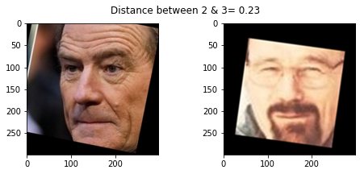

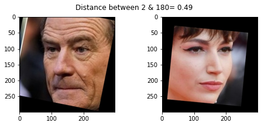

```python
def pair(sample1, sample2):
    plt.figure(figsize=(8,3))
    plt.suptitle(f'Distance between {sample1} & {sample2}= {dist_metric(embeddings[sample1], embeddings[sample2]):.2f}')
    plt.subplot(121)
    plt.imshow(load_image(metadata[sample1].image_path()))
    plt.subplot(122)
    plt.imshow(load_image(metadata[sample2].image_path()));

pair(2, 3)
pair(2, 180)
```

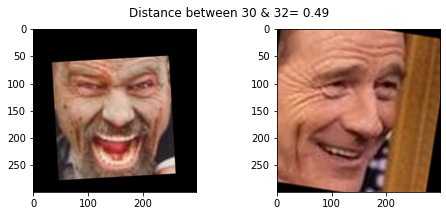

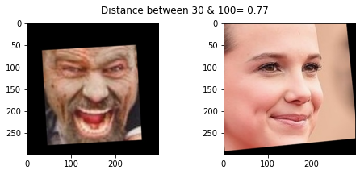

```python
pair(30, 32)
pair(30, 100)
```

# 6. Use PCA for dimensionality reduction. [2 Marks]

```python
#splitting data into train and test
train_idx = np.arange(metadata.shape[0]) % 9 != 0
test_idx = np.arange(metadata.shape[0]) % 9 == 0

# Features
X_train = np.array(embeddings)[train_idx]
X_test = np.array(embeddings)[test_idx]

# Labels
y_train = np.array([meta.name for meta in metadata[train_idx]])
y_test = np.array([meta.name for meta in metadata[test_idx]])

display(X_train.shape, X_test.shape, y_train.shape, y_test.shape)
```

```
(9573, 2622)
```

```
(1197, 2622)
```

```
(9573,)
```

```
(1197,)
```

```python
print(X_train[0])
print(X_test[0])
print(y_train[100])
print(y_test[0])
```

```
[ 0.00600171 -0.02976072 -0.01025872 ... -0.02052234 -0.0005966
 -0.0056927 ]
[ 0.02277908 -0.01083125 -0.0136546  ... -0.03247268 -0.0225797
  0.00022093]
pins_millie bobby brown
pins_Bryan Cranston
```

```python
#Label encoding for the traget varibale
from sklearn.preprocessing import LabelEncoder

le = LabelEncoder()
y_train_le = le.fit_transform(y_train)

print(le.classes_)
y_test_le = le.transform(y_test)
```

```
['pins_Aaron Paul' 'pins_Alvaro Morte' 'pins_Amanda Crew'
 'pins_Amaury Nolasco' 'pins_Anna Gunn' 'pins_Benedict Cumberbatch'
 'pins_Betsy Brandt' 'pins_Brenton Thwaites' 'pins_Brit Marling'
 'pins_Bryan Cranston' 'pins_Caity Lotz' 'pins_Cameron Monaghan'
 'pins_Chance Perdomo' 'pins_Chris Evans' 'pins_Chris Pratt'
 'pins_Cobie Smulders' 'pins_Danielle Panabaker' 'pins_Dave Franco'
 'pins_Dominic Purcell' 'pins_Dwayne Johnson' 'pins_Emilia Clarke'
 'pins_Emily Bett Rickards' 'pins_Emma Stone' 'pins_Gwyneth Paltrow'
 'pins_Henry Cavil' 'pins_Jason Momoa' 'pins_Jeremy Renner'
 'pins_Jesse Eisenberg' 'pins_Jim Parsons' 'pins_Jon Bernthal'
 'pins_Josh Radnor' 'pins_Kit Harington' 'pins_Krysten Ritter'
 'pins_Kumail Nanjiani' 'pins_Maisie Williams' 'pins_Mark Ruffalo'
 'pins_Martin Starr' 'pins_Melissa benoit' 'pins_Mike Colter'
 'pins_Morena Baccarin' 'pins_Morgan Freeman' 'pins_Natalie Portman '
 'pins_Neil Patrick Harris' 'pins_Paul Rudd' 'pins_Pedro Alonso'
 'pins_Peter Dinklage' 'pins_RJ Mitte' 'pins_Rami Melek'
 'pins_Robert Knepper' 'pins_Robin Taylor' 'pins_Ryan Reynolds'
 'pins_Sarah Wayne Callies' 'pins_Scarlett Johansson'
 'pins_Sebastian Stan' 'pins_Sophie Turner' 'pins_Stephen Amell'
 'pins_Sundar Pichai' 'pins_Thomas Middleditch' 'pins_Tom Cavanagh'
 'pins_Ursula Corbero' 'pins_Wentworth Miller' 'pins_Willa Holland'
 'pins_William Fichtner' 'pins_alexandra daddario'
 'pins_alycia debnam carey face' 'pins_amber heard face'
 'pins_anne hathaway' 'pins_barbara palvin face' 'pins_bellamy blake face'
 'pins_bill gates' 'pins_brie larson' 'pins_chadwick boseman face'
 'pins_david mazouz' 'pins_drake' 'pins_dua lipa face' 'pins_eliza taylor'
 'pins_elizabeth olsen face' 'pins_elon musk' 'pins_emma watson face'
 'pins_gal gadot face' 'pins_grant gustin face' 'pins_jason isaacs'
 'pins_jeff bezos' 'pins_kiernan shipka ' 'pins_kristen stewart face'
 'pins_lindsey morgan face' 'pins_margot robbie face' 'pins_maria pedraza'
 'pins_mark zuckerberg' 'pins_miguel herran' 'pins_millie bobby brown'
 'pins_rihanna' 'pins_robert downey jr face' 'pins_sean pertwee'
 'pins_selena gomez' 'pins_shakira' 'pins_tati gabrielle'
 'pins_taylor swift' 'pins_tom holland face' 'pins_zendaya']
```

```python
print('y_train_le : ', y_train_le)
print('y_test_le : ', y_test_le)
```

```
y_train_le :  [ 9  9  9 ... 71 71 71]
y_test_le :  [ 9  9  9 ... 71 71 71]
```

```python
#scaling/standardizing X train and test

from sklearn.preprocessing import StandardScaler

sc = StandardScaler()
X_train_scaled = sc.fit_transform(X_train)
X_test_scaled = sc.transform(X_test)
```

```python
print(X_train_scaled[10])
```

```
[ 0.82433445 -1.57066815 -2.0675284  ... -0.27738447 -1.56184719
 -1.59938006]
```

```python
print(X_test_scaled[1])
```

```
[-0.45661088  0.9194151  -0.61293218 ... -0.37316399  0.42665548
 -0.7371759 ]
```

```python
from sklearn.decomposition import PCA

cov_matrix = np.cov(X_train_scaled.T)

eig_values, eig_vectors = np.linalg.eig(cov_matrix)


total = sum(eig_values)
var_exp = [(i /total) * 100 for i in sorted(eig_values, reverse = True)]
cum_var_exp = np.cumsum(var_exp)

print('Cumulative Variance Explained', cum_var_exp)
```

```
Cumulative Variance Explained [ 13.63818256  18.97240715  22.93953173 ...  99.99999983  99.99999999
 100.        ]
```

```python
# Get index where cumulative variance explained is > threshold
thres = 95
res = list(filter(lambda i: i > thres, cum_var_exp))[0]
index = (cum_var_exp.tolist().index(res))
print(f'Index of element just greater than {thres}: {str(index)}')
```

```
Index of element just greater than 95: 346
```

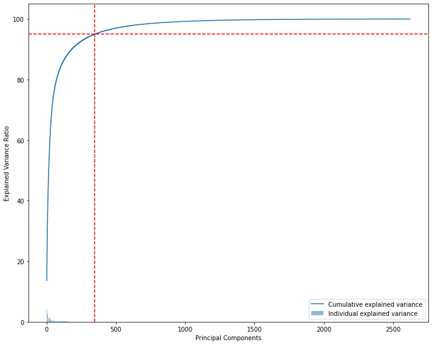

```python
plt.figure(figsize = (10 , 8))
plt.bar(range(1, eig_values.size + 1), var_exp, alpha = 0.5, align = 'center', label = 'Individual explained variance')
plt.step(range(1, eig_values.size + 1), cum_var_exp, where = 'mid', label = 'Cumulative explained variance')
plt.axhline(y = thres, color = 'r', linestyle = '--')
plt.axvline(x = index, color = 'r', linestyle = '--')
plt.ylabel('Explained Variance Ratio')
plt.xlabel('Principal Components')
plt.legend(loc = 'best')
plt.tight_layout()
plt.show()
```

```python
pca = PCA(n_components = index, random_state = 1, svd_solver = 'full', whiten = True)
pca.fit(X_train_scaled)
X_train_pca = pca.transform(X_train_scaled)
X_test_pca = pca.transform(X_test_scaled)
display(X_train_pca.shape, X_test_pca.shape)
```

```
(9573, 346)
```

```
(1197, 346)
```

# 7. Build an SVM classifier in order to map each image to its right person. [4 Marks]

```python
#Hyperparameter tuning to get the best parameters for best model performance and accuracy

from sklearn.model_selection import RandomizedSearchCV, GridSearchCV
from sklearn.svm import SVC

params_grid = [{'kernel': ['rbf'], 'gamma': [1e-2, 1e-3, 1e-4], 'C': [1, 10, 100, 1000], 'class_weight': ['balanced', None]}]

svm = GridSearchCV(SVC(random_state = 1), params_grid, cv = 3, scoring = 'f1_macro', verbose = 50, n_jobs = -1)
svm.fit(X_train_pca, y_train_le)

print('Best estimator found by grid search:')
print(svm.best_estimator_)
```

```
Fitting 3 folds for each of 24 candidates, totalling 72 fits
Best estimator found by grid search:
SVC(C=10, class_weight='balanced', gamma=0.0001, random_state=1)
```

```python
svc = SVC(C = 10, gamma = 0.001, random_state = 1)
svc.fit(X_train_pca, y_train_le)
print('SVC accuracy for train set: {0:.3f}'.format(svc.score(X_train_pca, y_train_le)))
```

```
SVC accuracy for train set: 1.000
```

```python
from sklearn.metrics import classification_report, confusion_matrix, accuracy_score

y_pred = svc.predict(X_test_pca)

print('Accuracy Score: {}'.format(accuracy_score(y_test_le, y_pred)))
```

[output not shown]

# 8. Import and display the the test images. [2 Marks]

Hint: ‘Benedict Cumberbatch9.jpg’ and ‘Dwayne Johnson4.jpg’ are the test images.

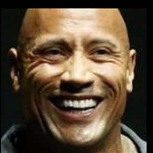

```python
from google.colab.patches import cv2_imshow
img_ben_c = cv2.imread('/content/drive/My Drive/CV-2 Dataset/Dwayne Johnson4.jpg')
cv2_imshow(img_ben_c)
```

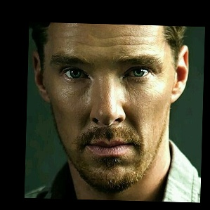

```python
from google.colab.patches import cv2_imshow
img_ben_c = cv2.imread('/content/drive/My Drive/CV-2 Dataset/Benedict Cumberbatch9.jpg')
cv2_imshow(img_ben_c)
```

# 9. Use the trained SVM model to predict the face on both test images. [4 Marks]

# checking the 1st test image

```python
#first image
sample_img = (img_ben_c/255.).astype(np.float32)
sample_img = cv2.resize(sample_img, (224, 224))
embedding = vgg_face_descriptor.predict(np.expand_dims(sample_img, axis = 0))[0]
embedding_scaled = sc.transform(embedding.reshape(1, -1))
sample_pred = svc.predict(pca.transform(embedding_scaled))
```

```python
pred_name = le.inverse_transform(sample_pred)[0].split('_')[-1].title().strip()
```

```python
pred_name
```

```
'Benedict Cumberbatch'
```

The model has predicted the face correctly as Benedict Cumberbatch

# Checking the 2nd test image

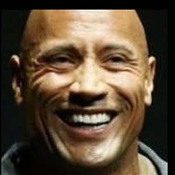

```python
img_rock = cv2.imread('/content/drive/My Drive/CV-2 Dataset/Dwayne Johnson4.jpg')
cv2_imshow(img_rock)
```

```python
sample_img2 = (img_rock/255.).astype(np.float32)
sample_img2 = cv2.resize(sample_img2, (224, 224))
embedding1 = vgg_face_descriptor.predict(np.expand_dims(sample_img2, axis = 0))[0]
embedding_scaled1 = sc.transform(embedding1.reshape(1, -1))
sample_pred = svc.predict(pca.transform(embedding_scaled1))
```

```python
pred_name1 = le.inverse_transform(sample_pred)[0].split('_')[-1].title().strip()
pred_name1
```

```
'Dwayne Johnson'
```

[output not shown]

The model has predicted the face correctly for 2nd test image as Dwayne Johnson